# TidyTuesday (2021-11-23) Dr. Who

2022-03-14

# TidyTuesday

Join the R4DS Online Learning Community in the weekly #TidyTuesday event! Every week we post a raw dataset, a chart or article related to that dataset, and ask you to explore the data. While the dataset will be “tamed”, it will not always be tidy! As such you might need to apply various R for Data Science techniques to wrangle the data into a true tidy format. The goal of TidyTuesday is to apply your R skills, get feedback, explore other’s work, and connect with the greater #RStats community! As such we encourage everyone of all skills to participate!

This was a follow along with [David Robinson’s analysis](https://youtu.be/89l_3Y53qMM) on the data set.

# Load the weekly Data

Download the weekly data and make available in the `tt` object.

```r
tt <- tt_load("2021-11-23")
```

```
## --- Compiling #TidyTuesday Information for 2021-11-23 ----
```

```
## --- There are 4 files available ---
```

```
## --- Starting Download ---
```

```
## --- Download complete ---
```

# Readme

Take a look at the readme for the weekly data to get insight on the dataset. This includes a data dictionary, source, and a link to an article on the data.

```r
tt
```

# Glimpse Data

Take an initial look at the format of the data available.

```r
tt %>%
  map(glimpse)
```

```
## Rows: 185
## Columns: 2
## $ story_number <chr> "157", "158", "159", "160a", "160b", "161", "162", "163",~
## $ writer       <chr> "Russell T Davies", "Russell T Davies", "Mark Gatiss", "R~
## Rows: 172
## Columns: 2
## $ story_number <chr> "157", "158", "159", "160a", "160b", "161", "162", "163",~
## $ director     <chr> "Keith Boak", "Euros Lyn", "Euros Lyn", "Keith Boak", "Ke~
## Rows: 172
## Columns: 12
## $ era             <chr> "revived", "revived", "revived", "revived", "revived",~
## $ season_number   <dbl> 1, 1, 1, 1, 1, 1, 1, 1, 1, 1, 1, 1, 1, 2, 2, 2, 2, 2, ~
## $ serial_title    <chr> NA, NA, NA, NA, NA, NA, NA, NA, NA, NA, NA, NA, NA, NA~
## $ story_number    <chr> "157", "158", "159", "160a", "160b", "161", "162", "16~
## $ episode_number  <dbl> 1, 2, 3, 4, 5, 6, 7, 8, 9, 10, 11, 12, 13, NA, 1, 2, 3~
## $ episode_title   <chr> "Rose", "The End of the World", "The Unquiet Dead", "A~
## $ type            <chr> "episode", "episode", "episode", "episode", "episode",~
## $ first_aired     <date> 2005-03-26, 2005-04-02, 2005-04-09, 2005-04-16, 2005-~
## $ production_code <chr> "1.1", "1.2", "1.3", "1.4", "1.5", "1.6", "1.7", "1.8"~
## $ uk_viewers      <dbl> 10.81, 7.97, 8.86, 7.63, 7.98, 8.63, 8.01, 8.06, 7.11,~
## $ rating          <dbl> 76, 76, 80, 82, 81, 84, 81, 83, 84, 85, 82, 86, 89, 84~
## $ duration        <dbl> 45, 44, 44, 45, 42, 45, 44, 45, 45, 45, 45, 45, 45, 60~
## Rows: 160
## Columns: 6
## $ season   <dbl> 1, 1, 1, 1, 1, 1, 1, 1, 1, 1, 1, 1, 1, 2, 2, 2, 2, 2, 2, 2, 2~
## $ ep_num   <dbl> 1, 2, 3, 4, 5, 6, 7, 8, 9, 10, 11, 12, 13, 0, 1, 2, 3, 4, 5, ~
## $ air_date <chr> "17 Mar. 2006", "17 Mar. 2006", "24 Mar. 2006", "31 Mar. 2006~
## $ rating   <dbl> 7.5, 7.5, 7.5, 7.0, 7.0, 8.7, 7.1, 8.4, 9.2, 9.2, 7.1, 8.7, 9~
## $ rating_n <dbl> 8301, 7279, 6804, 6543, 6337, 7211, 6255, 6889, 8383, 7702, 5~
## $ desc     <chr> "When ordinary shop-worker Rose Tyler meets a mysterious stra~
```

```
## $writers
## # A tibble: 185 x 2
##    story_number writer
##    <chr>        <chr>
##  1 157          Russell T Davies
##  2 158          Russell T Davies
##  3 159          Mark Gatiss
##  4 160a         Russell T Davies
##  5 160b         Russell T Davies
##  6 161          Robert Shearman
##  7 162          Russell T Davies
##  8 163          Paul Cornell
##  9 164a         Steven Moffat
## 10 164b         Steven Moffat
## # ... with 175 more rows
##
## $directors
## # A tibble: 172 x 2
##    story_number director
##    <chr>        <chr>
##  1 157          Keith Boak
##  2 158          Euros Lyn
##  3 159          Euros Lyn
##  4 160a         Keith Boak
##  5 160b         Keith Boak
##  6 161          Joe Ahearne
##  7 162          Brian Grant
##  8 163          Joe Ahearne
##  9 164a         James Hawes
## 10 164b         James Hawes
## # ... with 162 more rows
##
## $episodes
## # A tibble: 172 x 12
##    era     season_number serial_title story_number episode_number episode_title
##    <chr>           <dbl> <chr>        <chr>                 <dbl> <chr>
##  1 revived             1 <NA>         157                       1 Rose
##  2 revived             1 <NA>         158                       2 The End of th~
##  3 revived             1 <NA>         159                       3 The Unquiet D~
##  4 revived             1 <NA>         160a                      4 Aliens of Lon~
```

[output cut: 9 more lines]

```
## $imdb
## # A tibble: 160 x 6
##    season ep_num air_date     rating rating_n desc
##     <dbl>  <dbl> <chr>         <dbl>    <dbl> <chr>
##  1      1      1 17 Mar. 2006    7.5     8301 When ordinary shop-worker Rose Ty~
##  2      1      2 17 Mar. 2006    7.5     7279 The Doctor takes Rose to the year~
##  3      1      3 24 Mar. 2006    7.5     6804 The Doctor has great expectations~
##  4      1      4 31 Mar. 2006    7       6543 The Doctor returns Rose to her ow~
##  5      1      5 7 Apr. 2006     7       6337 The Slitheen have infiltrated Par~
##  6      1      6 14 Apr. 2006    8.7     7211 The TARDIS is drawn to an alien m~
##  7      1      7 21 Apr. 2006    7.1     6255 In the year 200,000 the Doctor di~
##  8      1      8 28 Apr. 2006    8.4     6889 Rose asks The Doctor to take her ~
##  9      1      9 5 May 2006      9.2     8383 When a spaceship crashes in the m~
## 10      1     10 12 May 2006     9.2     7702 The gas mask zombies are on the r~
## # ... with 150 more rows
```

```r
directors <- tt$directors %>% janitor::clean_names()
episodes <- tt$episodes %>% janitor::clean_names() %>%
  fill(season_number)%>%
  mutate(episode_id = paste0(season_number,".",coalesce(as.character(episode_number), "X"),".",episode_title),
        episode_id = fct_reorder(episode_id, first_aired),
        episode_title = fct_reorder(episode_title, first_aired),
        overall_episode_number = as.integer(episode_title))
writers <- tt$writers %>% janitor::clean_names()
imdb <- tt$imdb %>% janitor::clean_names()
```

```r
episodes %>%
  select(first_aired, uk_viewers, rating, duration) %>%
  summary()
```

```
##   first_aired           uk_viewers        rating         duration
##  Min.   :2005-03-26   Min.   : 4.69   Min.   :76.00   Min.   :41.00
##  1st Qu.:2008-04-10   1st Qu.: 6.55   1st Qu.:82.00   1st Qu.:45.00
##  Median :2011-09-27   Median : 7.37   Median :84.00   Median :45.00
##  Mean   :2012-06-25   Mean   : 7.53   Mean   :84.19   Mean   :49.03
##  3rd Qu.:2015-12-10   3rd Qu.: 8.22   3rd Qu.:86.00   3rd Qu.:50.00
##  Max.   :2021-12-05   Max.   :13.31   Max.   :91.00   Max.   :77.00
##                       NA's   :5       NA's   :4       NA's   :3
```

```r
episodes %>% select(era) %>% table(useNA = "ifany")
```

```
## .
## revived
##     172
```

```r
episodes %>% select(season_number) %>% table(useNA = "ifany")
```

```
## .
##  1  2  3  4  5  6  7  8  9 10 11 12 13
## 13 14 14 19 13 14 17 12 14 14 11 11  6
```

```r
episodes %>% select(episode_number) %>% table(useNA = "ifany")
```

```
## .
##    1    2    3    4    5    6    7    8    9   10   11   12   13 <NA>
##   15   15   14   14   14   13   12   12   12   12   10   10    7   12
```

```r
episodes %>% select(serial_title) %>% table(useNA = "ifany")
```

```
## .
## Flux <NA>
##    6  166
```

```r
episodes %>% select(story_number) %>% table(useNA = "ifany")
```

```
## .
##  157  158  159 160a 160b  161  162  163 164a 164b  165 166a 166b  167  168  169
##    1    1    1    1    1    1    1    1    1    1    1    1    1    1    1    1
##  170  171 172a 172b  173 174a 174b  175  176 177a 177b  178  179  180  181 182a
##    1    1    1    1    1    1    1    1    1    1    1    1    1    1    1    1
## 182b  183  184 185a 185b  186 187a 187b 187c  188  189  190  191 192a 192b  193
##    1    1    1    1    1    1    1    1    1    1    1    1    1    1    1    1
##  194 195a 195b  196  197 198a 198b  199  200  201 202a 202b  203  204  205 206a
##    1    1    1    1    1    1    1    1    1    1    1    1    1    1    1    1
## 206b  207  208 209a 209b  210  211 212a 212b  213 214a 214b  215  216 217a 217b
##    1    1    1    1    1    1    1    1    1    1    1    1    1    1    1    1
##  218  219  220  221  222  223  224  225  226  227  228  229  230  231  232  233
##    1    1    1    1    1    1    1    1    1    1    1    1    1    1    1    1
##  234  235  236  237  238  239  240  241  242  243  244  245  246  247  248  249
##    1    1    1    1    1    1    1    1    1    1    1    1    1    1    1    1
##  250  251 252a 252b  253 254a 254b 255a 255b  256  257 258a 258b  259  260  261
##    1    1    1    1    1    1    1    1    1    1    1    1    1    1    1    1
##  262  263  264  265  266  267  268  269  270  271  272  273  274 275a 275b  276
##    1    1    1    1    1    1    1    1    1    1    1    1    1    1    1    1
##  277  278  279  280  281  282  283  284  285  286  287 288a 288b  289  290  291
##    1    1    1    1    1    1    1    1    1    1    1    1    1    1    1    1
##  292  293  294 295a 295b  296 297a 297b 297c 297d 297e 297f
##    1    1    1    1    1    1    1    1    1    1    1    1
```

```r
episodes %>% select(type) %>% table(useNA = "ifany")
```

```
## .
## episode special
##     153      19
```

```r
episodes %>% select(production_code) %>% table(useNA = "ifany")
```

```
## .
##  1.1 1.11 1.12 1.13  1.2  1.3  1.4  1.5  1.6  1.7  1.8  1.9  2.1 2.10 2.11 2.12
##    4    2    2    2    2    2    2    2    2    2    2    2    2    2    2    2
## 2.13  2.2  2.3  2.4  2.5  2.6  2.7  2.8  2.9  2.X   2X  3.1 3.10 3.11 3.12 3.13
##    2    2    2    2    2    2    2    2    2    1    1    1    1    1    1    1
##  3.2  3.3  3.4  3.5  3.6  3.7  3.8  3.9   3X  4.1 4.10 4.11 4.12 4.13 4.14 4.15
##    1    1    1    1    1    1    1    1    1    1    1    1    1    1    1    1
## 4.16 4.17 4.18  4.2  4.3  4.4  4.5  4.6  4.7  4.8  4.9   4X <NA>
##    1    1    1    1    1    1    1    1    1    1    1    1   85
```

```r
# episodes %>% select(episode_id) %>% table(useNA = "ifany")
```

## Examining NA values

```r
episodes %>%
  filter(is.na(production_code)) %>% View()
```

We will be removing `serial_title`, `era`, and `production_code` since they will not be used in any future analysis for this set.

```r
episodes <- episodes %>%
  select(-serial_title, -production_code, -era)

episodes %>% names()
```

```
##  [1] "season_number"          "story_number"           "episode_number"
##  [4] "episode_title"          "type"                   "first_aired"
##  [7] "uk_viewers"             "rating"                 "duration"
## [10] "episode_id"             "overall_episode_number"
```

Then re-examine NA values:

```r
episodes %>%
  summarize(across(everything(), ~ sum(is.na(.)))) %>%
  tidyr::pivot_longer(everything()) %>%
  arrange(desc(value)) %>%
  deframe()
```

```
##         episode_number             uk_viewers                 rating
##                     12                      5                      4
##               duration          episode_title overall_episode_number
##                      3                      1                      1
##          season_number           story_number                   type
##                      0                      0                      0
##            first_aired             episode_id
##                      0                      0
```

NA counting methodology was taken from [stackexchange](https://stackoverflow.com/questions/63198917/using-tidyverse-pipeline-to-count-nas-and-reorder)

# Visualize

Using your processed dataset, create your unique visualization.

We will examine the viewership across all the seasons.

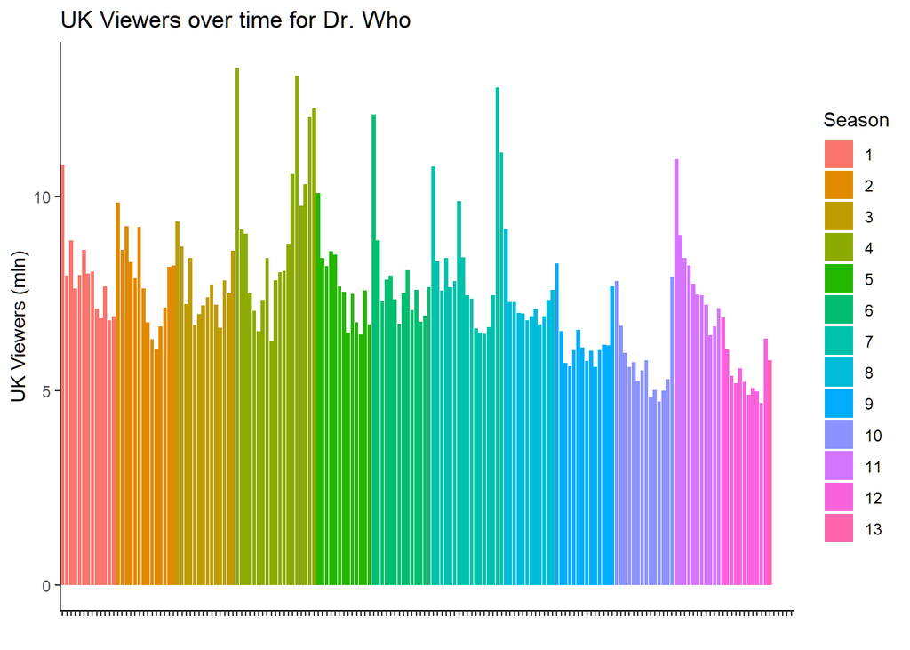

```r
episodes %>%
  #filter(season_number <= 4) %>%
  ggplot(aes(episode_title, uk_viewers, fill = factor(season_number))) +
  geom_col() +
  scale_x_discrete(name = "") +
  scale_y_continuous(name = "UK Viewers (mln)") +
  scale_fill_discrete(name = "Season") +
  #theme(axis.text.x = element_text(angle = 90, hjust = 1)) +
  theme(axis.text.x = element_blank()) +
  ggtitle("UK Viewers over time for Dr. Who")
```

Similarly, look at ratings:

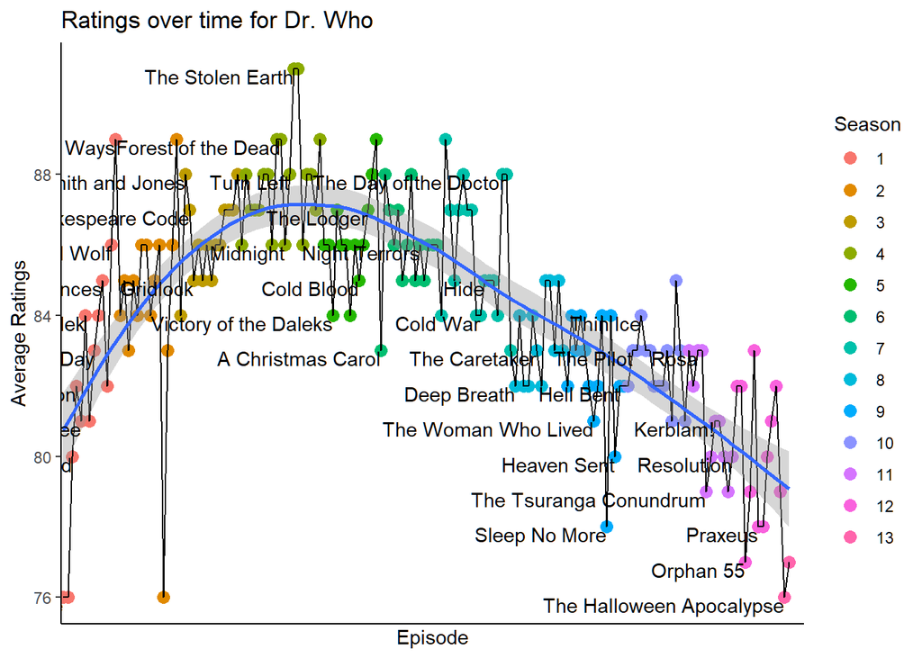

```r
episodes %>%
  ggplot(aes(as.numeric(episode_title), rating)) +
  geom_point(size = 3, aes(color = factor(season_number))) +
  geom_line(group = 1) +
  geom_smooth(method = "loess") +
  geom_text(aes(label = episode_title), hjust = 1, vjust = 1, check_overlap = TRUE) +
  scale_x_discrete(name = "Episode") +
  scale_y_continuous(name = "Average Ratings") +
  scale_color_discrete(name = "Season") +
  theme(axis.text.x = element_blank()) +
  ggtitle("Ratings over time for Dr. Who")
```

```r
summarize_episodes <- function(tbl) {
  tbl %>%
    summarize(median_rating = median(rating, na.rm = TRUE),
              average_rating = mean(rating, na.rm = TRUE),
              median_viewers = median(uk_viewers, na.rm = TRUE),
              average_viewers = mean(uk_viewers, na.rm = TRUE),
              n_episodes = n(),
              t_test = list(broom::tidy(t.test(rating[!is.na(rating)])))
              ) %>%
              unnest(t_test) %>%
  arrange(desc(n_episodes))
}
```

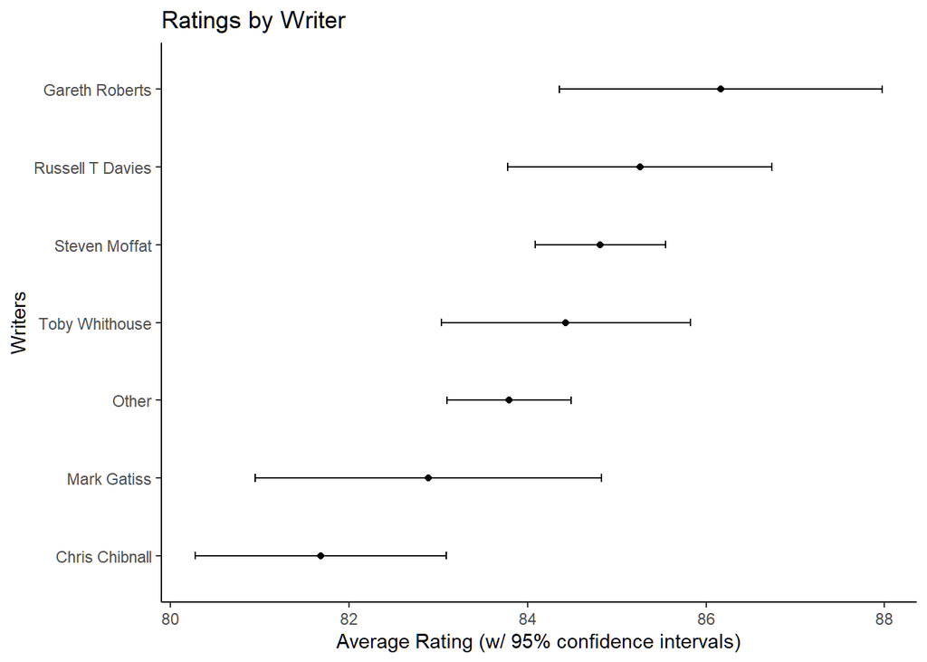

```r
episodes %>%
  inner_join(writers, by ="story_number") %>%
  group_by(writer = fct_lump(writer, 6)) %>%
             summarize_episodes() %>%
  mutate(writer = fct_reorder(writer, average_rating)) %>%
  ggplot() +
  aes(x = average_rating, y = writer) +
  geom_point() +
  geom_errorbarh(aes(xmin = conf.low, xmax = conf.high), height = 0.1) +
  scale_x_continuous(name = "Average Rating (w/ 95% confidence intervals)") +
  scale_y_discrete(name = "Writers") +
  ggtitle("Ratings by Writer")
```

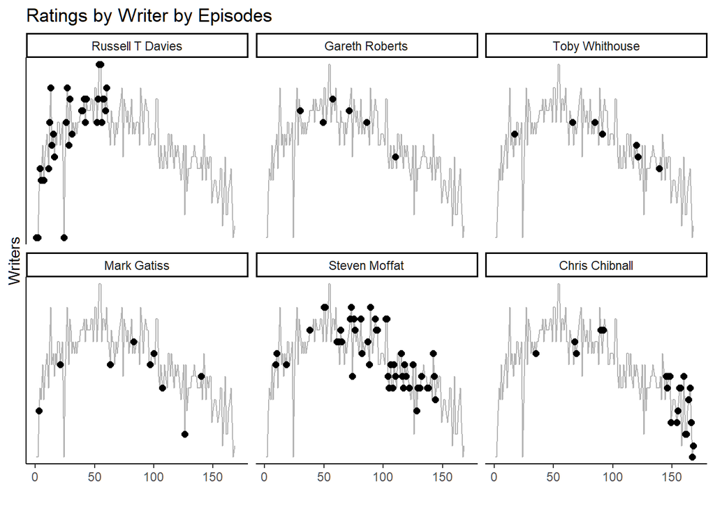

```r
episodes %>%
  inner_join(writers, by ="story_number") %>%
  mutate(writer = fct_lump(writer, 6),
         writer = fct_reorder(writer, as.integer(episode_title))) %>%
  filter(writer != "Other") %>%
  ggplot() +
  aes(x = as.integer(episode_title), y = rating) +
  geom_point(size = 2) +
  geom_line(data = episodes, alpha = 0.3) +
  facet_wrap(~ writer) +
  scale_x_continuous(name = "") +
  scale_y_discrete(name = "Writers") +
  ggtitle("Ratings by Writer by Episodes")
```

Statistical tests for whether writer makes unpopular or popular episodes?

```r
writers_spread <- episodes %>%
  inner_join(writers, by ="story_number") %>%
  mutate(writer = fct_lump(writer, 6),
         value = 1) %>%
  filter(writer != "Other") %>%
  pivot_wider(names_from = "writer", values_from = "value", values_fill = 0) %>%
  janitor::clean_names()
  #spread(writer, value, fill = 0) %>% View()
```

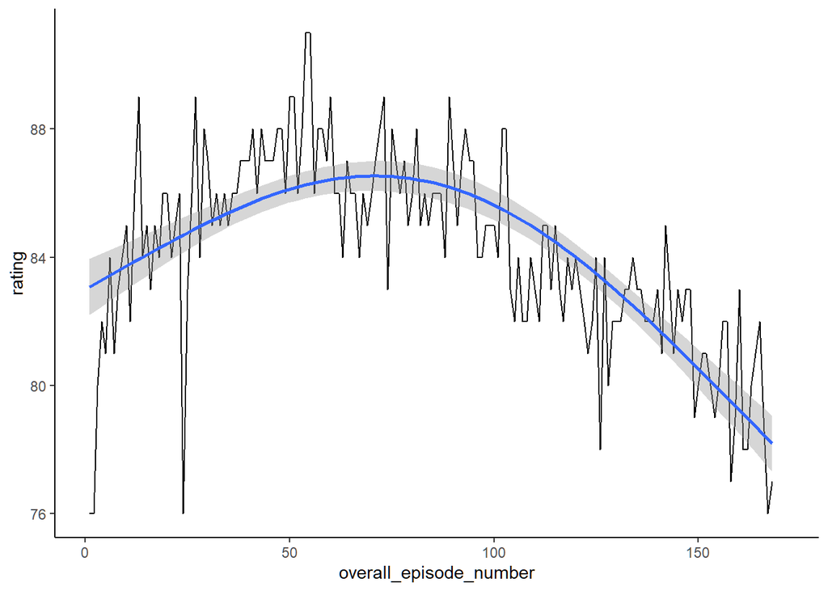

```r
episodes %>%
  ggplot() +
  aes(overall_episode_number, rating) +
  geom_line() +
  geom_smooth(method = "gam", formula = y ~ s(x, k = 3))
```

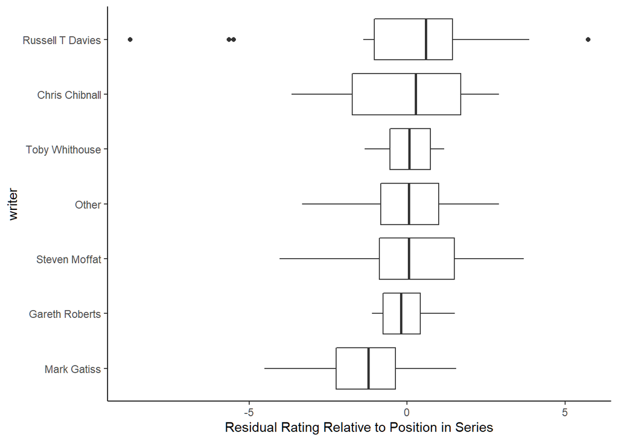

```r
library(splines)

episode_predictions <- lm(rating ~
     ns(overall_episode_number, 3), episodes) %>%
  broom::augment(data = episodes %>% filter(!is.na(rating))) %>%
  select(episode_title, story_number, rating, .fitted, .resid)

episode_predictions %>%
  inner_join(writers) %>%
  mutate(writer = fct_lump(writer, 6),
         writer = fct_reorder(writer, .resid)) %>%
  ggplot(aes(.resid, writer)) +
  geom_boxplot() +
  scale_x_continuous(name = "Residual Rating Relative to Position in Series")
```

```r
lm(rating ~
   ns(overall_episode_number, 3) +
   russell_t_davies +
   mark_gatiss +
     chris_chibnall +
     steven_moffat,
   writers_spread) %>%
  #aov() %>%
  summary()
```

```
##
## Call:
## lm(formula = rating ~ ns(overall_episode_number, 3) + russell_t_davies +
##     mark_gatiss + chris_chibnall + steven_moffat, data = writers_spread)
##
## Residuals:
##     Min      1Q  Median      3Q     Max
## -8.8020 -1.1335  0.0469  1.3082  5.8532
##
## Coefficients:
##                                Estimate Std. Error t value Pr(>|t|)
## (Intercept)                     80.8801     0.9604  84.216  < 2e-16 ***
## ns(overall_episode_number, 3)1  -0.8054     1.0974  -0.734    0.465
## ns(overall_episode_number, 3)2   7.9623     1.8475   4.310 3.51e-05 ***
## ns(overall_episode_number, 3)3  -6.3041     1.0823  -5.825 5.48e-08 ***
## russell_t_davies                 0.3156     0.8114   0.389    0.698
## mark_gatiss                     -1.3479     0.9469  -1.424    0.157
## chris_chibnall                  -0.2828     0.9577  -0.295    0.768
## steven_moffat                    0.2298     0.7089   0.324    0.746
## ---
## Signif. codes:  0 '***' 0.001 '**' 0.01 '*' 0.05 '.' 0.1 ' ' 1
##
## Residual standard error: 2.093 on 113 degrees of freedom
##   (4 observations deleted due to missingness)
## Multiple R-squared:  0.6166, Adjusted R-squared:  0.5928
## F-statistic: 25.96 on 7 and 113 DF,  p-value: < 2.2e-16
```

# Save Image

Save your image for sharing. Be sure to use the `#TidyTuesday` hashtag in your post on twitter!

```r
# This will save your most recent plot
ggsave(
  filename = "My TidyTuesday Plot.png",
  device = "png")
```